# Exploratory report on juvenile snowshoe hares

Sage Kime

11/15/2020

## 1. Introduction

This report provides an exploratory overview of differences in weight of juvenile hares from three site locations within the Tanana Valley (Bonanza Riparian, Bonanza Mature, and Bonanza Black Spruce) in Alaska from 1999-2012 (Kielland et al. 2017). Total annual counts of juvenile hares throughout combined locations will be explored before a more in-depth analysis of juvenile hare weight compared by both sex and site location. Finally, the relationship between juvenile hare weight and hind foot length will be explored and we will determine whether a linear relationship exists.

## 2. Data and analyses

Snowshoe hare physical data was made available by Dr. Knut Kielland and his colleagues at Bonanza Creek Long Term Ecological Research (LTER) in Alaska. The data contain observations from 1998-2012 collected in the Tanana Valley. Following exploratory data visualization, weights between male and female juvenile hares are compared by two-sample t-tests using a significance level ($\alpha$) of 0.05 throughout. Differences between groups are described by Cohen’s *d* effect size. The relationship between hind foot length and weight is explored by simple linear regression. All analyses are in R version 4.0.2 using RStudio version 1.3.1056.

## 3. Exploratory findings

### A. Annual juvenile hare trap counts

Total juvenile hare trappings were counted per year. Site location (grid) and sex were not included as variables, but they could be useful to investigate moving forward. In addition, duplicate traps were not considered in this analysis.

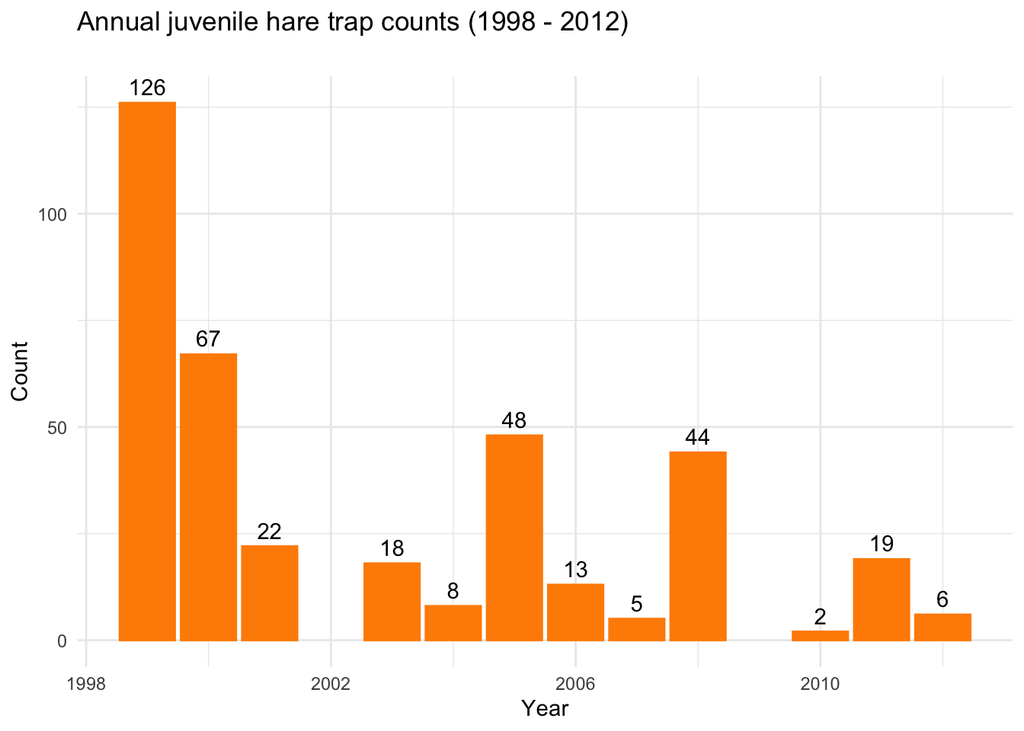

**Figure 1:** This graph shows the annual counts of juvenile hare trappings across all sites in the study from Kielland, K. et al. (2017).

### B. Visualize juvenile hare weights

Juvenile hare weights (all in grams) were compared across the 3 sites, and sex was also used as a variable. Sex is classified as Male, Female, or NA (undetermined).

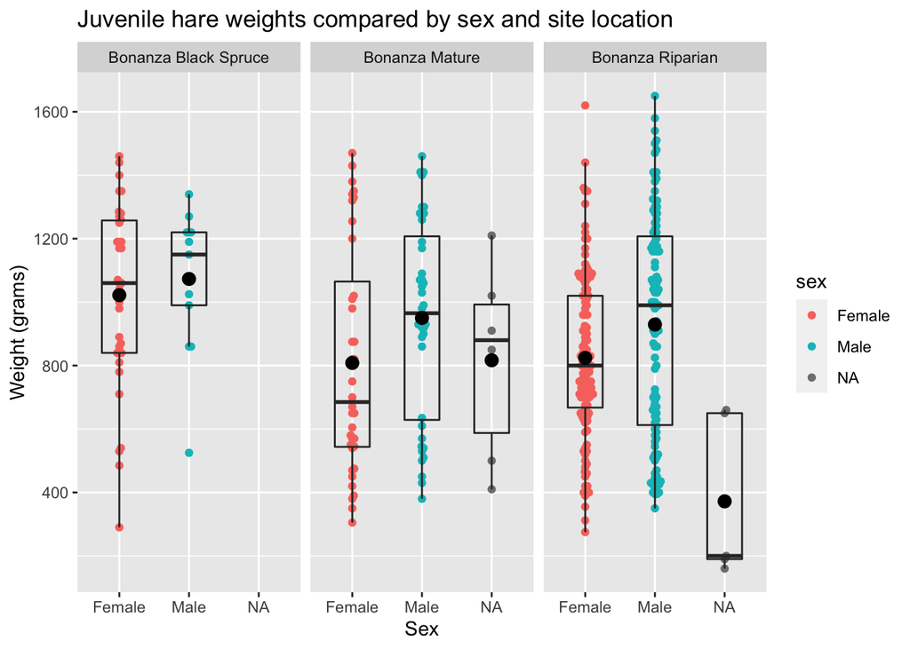

**Figure 2:** Weight observations (g) for juvenile hare trappings at three site locations (Bonanza Black Spruce, Bonanza Mature, and Bonanza Riparian). Pink (female), blue (male) and gray (NA) points indicate individual observations for weight (grams) of juvenile hares based on sex. Box endpoints indicate the 25<sup>th</sup> and 75<sup>th</sup> percentile values; the black point within the box indicates the mean value for each sex, and the black line indicates the median value. Data: Kielland, K. et al. (2017)

### C. Juvenile weight comparison (male & female snowshoe hares)

Table 1. Descriptive statistics (mean, standard deviation, and sample size) for weights of male and female juveline hares. Data: Kielland, K. et al. (2017).

| Sex | Mean Weight (g) | Standard Deviation (g) | Sample Size (n) |
| --- | --- | --- | --- |
| Female | 855.3909 | 292.2526 | 200 |
| Male | 945.8589 | 333.2151 | 163 |

The absolute difference in means between male and female juvenile hares is approximately 90.47 grams, which is a 10.05% difference. The difference in means is significant according to the Welch’s two-sample t-test: t(325.02) = -2.71, p = 0.01, but the effect size is small: Cohen’s d = 0.29.

### D. Relationship between juvenile weight and hind foot length

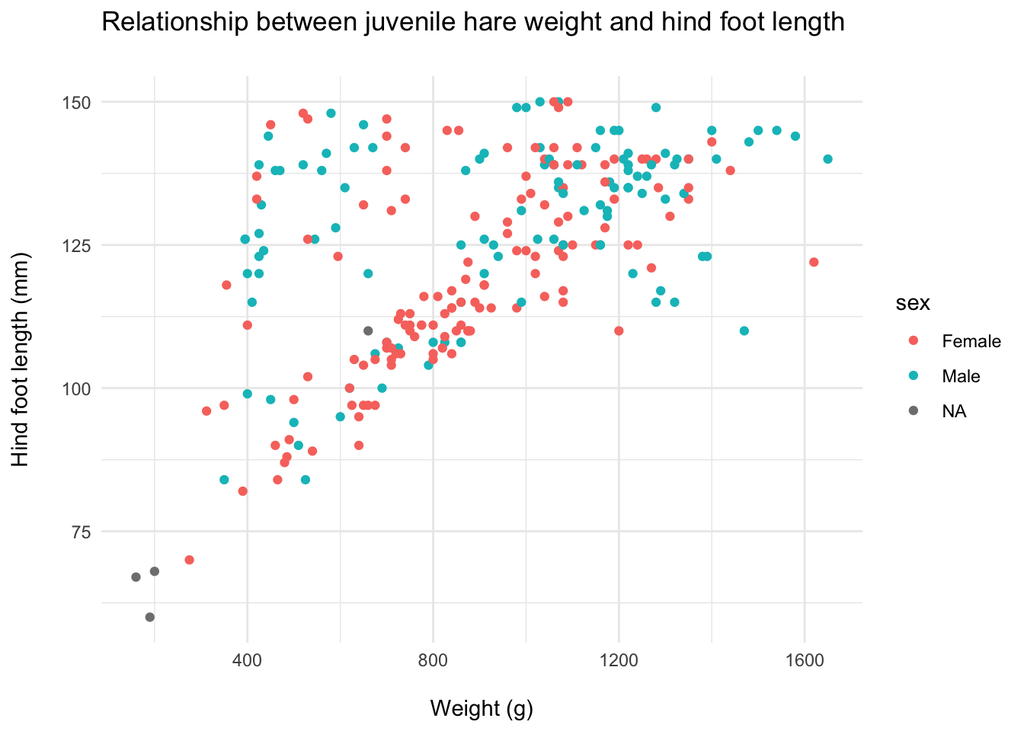

**Figure 3:** Relationship between hind foot length (mm) and weight (g) for male and female juvenile hares across all site locations. Points indicate individual hare measurements, and the colors indicate sex according to the legend.

For this study, the relationship between hind foot length and weight was explored across all juvenile hares; further analysis is needed to compare the relationship between hind foot length and weight within each site location, and should also include sex as an additional variable.

The simple linear model returned a R<sup>2</sup> value of 0.299, meaning only 29.9% of variance in juvenile hare weight is explained by this model that uses hare hind foot length as the explanatory variable. The average predicted slope was $\beta$ = 9.52 g, meaning for each one millimeter increase in hind foot length we can expect an average increase in hare weight of 9.52 g. Pearson’s r was also used to test correlation resulting in a moderate positive correlation with r = 0.547.

Despite these results, I do not think a linear relationship is the best way to describe the relationship between juvenile hare weight and hind foot length. The initial exploratory data visualization between juvenile hare weight and hind foot length did not appear to have a linear trend. Using the plot() function, we can see that the residuals are not homoscedastic. In fact, the residuals seem to be spread in a non-random way skewed to the right over the x-axis - I believe this means the residuals are heteroscedastic and not fit for a linear model. Additionally, the QQ-plot does not follow a linear trend - a large section of residual points are curved below the linear prediction line.

## Summary

Exploratory data analysis reveals the following initial findings:

- Male juvenile hares have a larger mean weight than females (the difference is significant, but the effect size is small)
- Weights for juvenile hares tend to be larger in the Bonanza Black Spruce site than the other sites
- Hind foot length and weight do not appear to have a linear relationship in juvenile hares

Next steps:

- Determine whether another type of relationship exists between hind foot length and weight
- Use a one-way ANOVA to compare mean weights between hares at various sites

## Citations

Kielland, K., F.S. Chapin, R.W. Ruess, and Bonanza Creek LTER. 2017. Snowshoe hare physical data in Bonanza Creek Experimental Forest: 1999-Present ver 22. Environmental Data Initiative. https://doi.org/10.6073/pasta/03dce4856d79b91557d8e6ce2cbcdc14 (Accessed 2020-11-16).